# Performance benefit by using compiled model definitions in mkin

Johannes Ranke

2016-09-10

## Benchmark for a model that can also be solved with Eigenvalues

This evaluation is taken from the example section of mkinfit. When using an mkin version equal to or greater than 0.9-36 and a C compiler (gcc) is available, you will see a message that the model is being compiled from autogenerated C code when defining a model using mkinmod. The `mkinmod()` function checks for presence of the gcc compiler using

```r
Sys.which("gcc")
```

```
##            gcc
## "/usr/bin/gcc"
```

First, we build a simple degradation model for a parent compound with one metabolite.

```r
library("mkin")
SFO_SFO <- mkinmod(
  parent = mkinsub("SFO", "m1"),
  m1 = mkinsub("SFO"))
```

```
## Successfully compiled differential equation model from auto-generated C code.
```

We can compare the performance of the Eigenvalue based solution against the compiled version and the R implementation of the differential equations using the microbenchmark package.

```r
library("microbenchmark")
library("ggplot2")
mb.1 <- microbenchmark(
  "deSolve, not compiled" = mkinfit(SFO_SFO, FOCUS_2006_D,
                                    solution_type = "deSolve",
                                    use_compiled = FALSE, quiet = TRUE),
  "Eigenvalue based" = mkinfit(SFO_SFO, FOCUS_2006_D,
                               solution_type = "eigen", quiet = TRUE),
  "deSolve, compiled" = mkinfit(SFO_SFO, FOCUS_2006_D,
                                solution_type = "deSolve", quiet = TRUE),
  times = 3, control = list(warmup = 0))
smb.1 <- summary(mb.1)
print(mb.1)
```

```
## Unit: milliseconds
##                   expr       min        lq      mean    median        uq
##  deSolve, not compiled 6410.2240 6437.0229 6461.3866 6463.8218 6486.9680
##       Eigenvalue based  887.5697  915.3026  929.6279  943.0355  950.6570
##      deSolve, compiled  737.4060  745.6645  749.1956  753.9229  755.0903
##        max neval cld
##  6510.1142     3   c
##   958.2786     3  b
##   756.2578     3 a
```

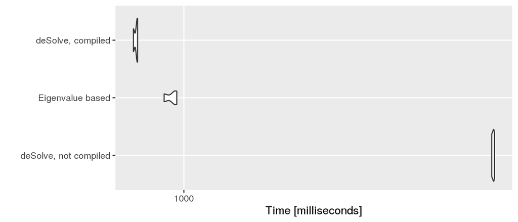

```r
autoplot(mb.1)
```

We see that using the compiled model is by a factor of 8.6 faster than using the R version with the default ode solver, and it is even faster than the Eigenvalue based solution implemented in R which does not need iterative solution of the ODEs:

```r
rownames(smb.1) <- smb.1$expr
smb.1["median"]/smb.1["deSolve, compiled", "median"]
```

```
##                         median
## deSolve, not compiled 8.573584
## Eigenvalue based      1.250838
## deSolve, compiled     1.000000
```

## Benchmark for a model that can not be solved with Eigenvalues

This evaluation is also taken from the example section of mkinfit.

```r
FOMC_SFO <- mkinmod(
  parent = mkinsub("FOMC", "m1"),
  m1 = mkinsub( "SFO"))
```

```
## Successfully compiled differential equation model from auto-generated C code.
```

```r
mb.2 <- microbenchmark(
  "deSolve, not compiled" = mkinfit(FOMC_SFO, FOCUS_2006_D,
                                    use_compiled = FALSE, quiet = TRUE),
  "deSolve, compiled" = mkinfit(FOMC_SFO, FOCUS_2006_D, quiet = TRUE),
  times = 3, control = list(warmup = 0))
smb.2 <- summary(mb.2)
print(mb.2)
```

```
## Unit: seconds
##                   expr       min        lq      mean    median       uq
##  deSolve, not compiled 13.370040 13.424534 13.501075 13.479027 13.56659
##      deSolve, compiled  1.336599  1.336707  1.339399  1.336815  1.34080
##        max neval cld
##  13.654158     3   b
##   1.344784     3  a
```

```r
smb.2["median"]/smb.2["deSolve, compiled", "median"]
```

```
##   median
## 1     NA
## 2     NA
```

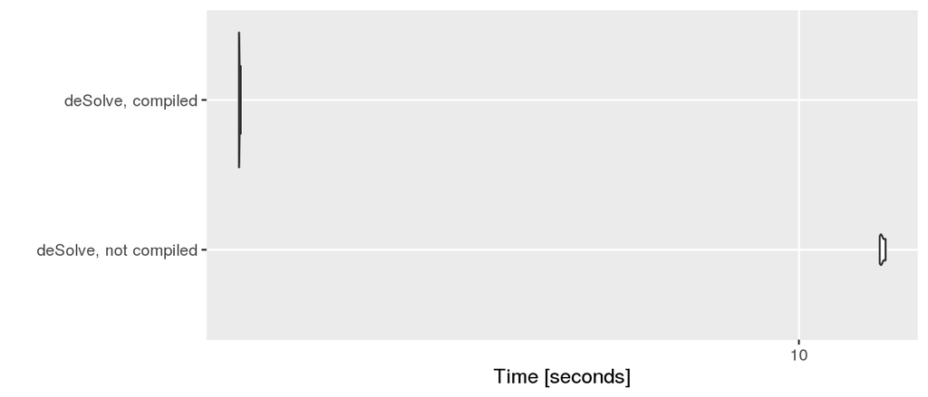

```r
autoplot(mb.2)
```

This vignette was built with mkin 0.9.44.9000 on

```
## CPU model: Intel(R) Core(TM) i7-4710MQ CPU @ 2.50GHz
```